# text_lab

Courtney Kennedy, Josephine Johannes, Maggie Tran

10/20/2021

# Steps:

**Steps:**

1. Find newspapers that correspond to a specific region in the United States and download multiple articles as one text file
2. Load the files and essential libraries
3. Find the frequency of words per region by tokenizing the document
4. Use Lexicons that help classify the sentiment of the respective words

## West Coast

### Word Frequency

1. The first step in the process is finding the frequency of words per region.

```r
#Load in west coast file
cali_inag <- read_lines("cali-news.txt")

#Create tibble data structure
cali_inag <- tibble(cali_inag)

#Convert to character data type
cali_inag$cali_inag <- as.character(cali_inag$cali_inag)

#Determine Word Frequency in west coast
cali_inag <- cali_inag %>%
  unnest_tokens(word, cali_inag)%>%
  anti_join(stop_words)%>%
  count(word, sort=TRUE)

#Top word frequencies
head(cali_inag, 10)
```

```
## # A tibble: 10 x 2
##    word           n
##    <chr>      <int>
##  1 climate      427
##  2 change       279
##  3 90           243
##  4 78           235
##  5 california   155
##  6 89           151
##  7 heat         126
##  8 global       124
##  9 2021         122
## 10 angeles      121
```

### Sentiment Analysis

2. Using the word frequency from step 1, we use lexicons that help to classify the words in the documents using sentiment.

```r
# Inner join with sentiments
cali_sentiment_affin <- cali_inag %>%
  inner_join(get_sentiments("afinn"))

cali_sentiment_nrc <- cali_inag %>%
  inner_join(get_sentiments("nrc"))

cali_sentiment_bing <- cali_inag %>%
  inner_join(get_sentiments("bing"))
```

```r
# Count of word sentiments in West Coast region
table(cali_sentiment_bing$sentiment)
```

```
##
## negative positive
##      523      313
```

```r
table(cali_sentiment_nrc$sentiment)
```

```
##
##        anger anticipation      disgust         fear          joy     negative
##          197          227          127          283          169          489
##     positive      sadness     surprise        trust
##          572          225          123          340
```

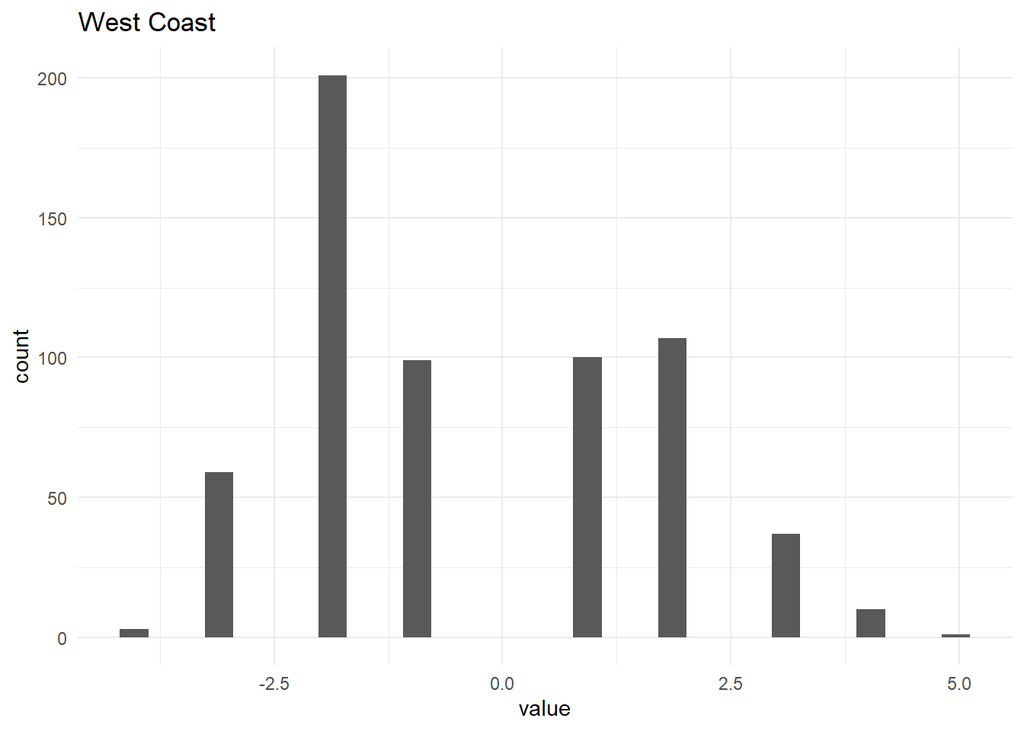

```r
# Distribution of positive and negative word sentiments
west_sent_plot <- ggplot(data = cali_sentiment_affin,
       aes(x=value)
        )+
  geom_histogram()+
  ggtitle("West Coast")+
  theme_minimal()

west_sent_plot
```

The sentiment analysis using bing shows that the west coast uses more negative words than positive words. The nrc sentitiment contradicts this and has a higher positive sentiment word count that negative, but also adds to this by showing that most of the words invoke a feeling of trust and then the second highest feeling is fear. The affin sentiment distribution shows that there is a slight favor of negative sentiment words in the west coast region’s newspapers. Overall it appears that the negative sentiment is more common, and it most likely correlates to the more “doomsday” approach that more liberal regions have, such as the west coast, since the approach is instilling fear to promote change in current behaviors. There is also a use of trust especially towards new technology and this is where the trust and positive sentiment most likely comes in.

### Word Cloud

3. Create a word cloud to see the popularity of the words

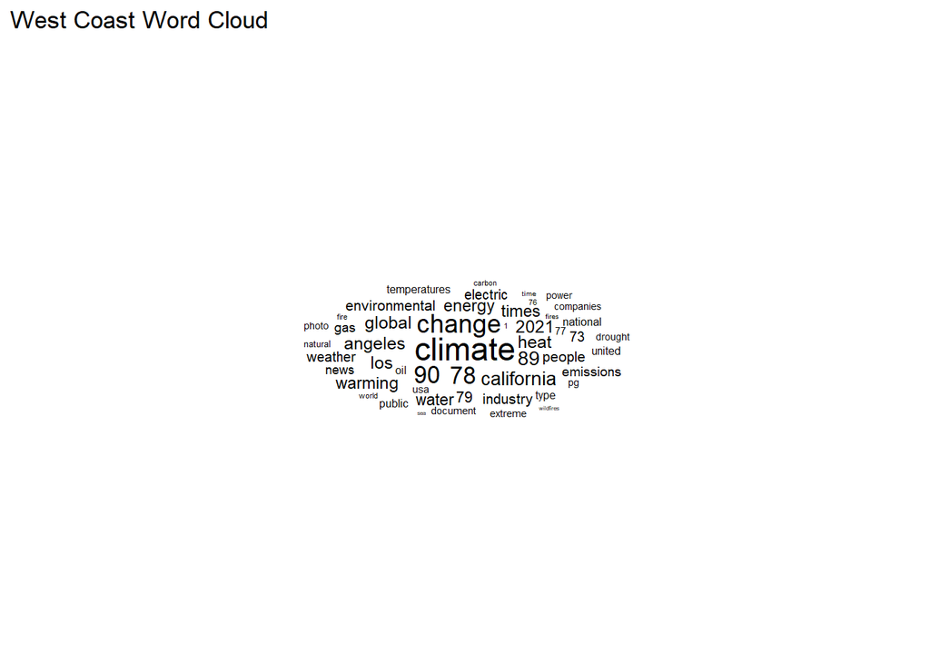

```r
set.seed(42)
west_cloud <- ggplot(cali_inag[1:50,], aes(label = word, size = n)
       ) +
  geom_text_wordcloud() +
  theme_minimal() +
  ggtitle("West Coast Word Cloud")

west_cloud
```

We see that the most common words from the west coast region are some expected terms: climate, change, los, angeles, and then some other words that indicate the west coast’s main concerns with climate change: heat, water, temperatures, warming, extreme, drought, and fire. Overall these more specific words correlate with the climate change symptoms that the west coast is experiencing such as water shortages, extreme temperatures, and wildfires. Some other popular words seem to correlate with the environmental science industry that is fighting climate change such as electric, industry, environmental, power, companies, and emissions, which all make sense given that the west coast is a hub of environmental research and clean industries.

## Midwest Region

### Word Frequency

1. The first step in the process is finding the frequency of words per region.

```r
#Load in midwest file
midwest_inag <- read_lines("midwest.txt")

#Create tibble data structure
midwest_inag <- tibble(midwest_inag)

#Convert to character data type
midwest_inag$midwest_inag <- as.character(midwest_inag$midwest_inag)

#Determine Word Frequency in west coast
midwest_inag <- midwest_inag %>%
  unnest_tokens(word, midwest_inag)%>%
  anti_join(stop_words)%>%
  count(word, sort=TRUE)

#Top word frequencies
head(midwest_inag, 10)
```

```
## # A tibble: 10 x 2
##    word        n
##    <chr>   <int>
##  1 climate   650
##  2 change    461
##  3 90        218
##  4 78        172
##  5 89        145
##  6 energy    125
##  7 lake      121
##  8 chicago   106
##  9 weather    98
## 10 73         91
```

### Sentiment Analysis

2. Using the word frequency from step 1, we use lexicons that help to classify the words in the documents using sentiment.

```r
# Inner join with sentiments

midwest_sentiment_affin <- midwest_inag %>%
  inner_join(get_sentiments("afinn"))

midwest_sentiment_nrc <- midwest_inag %>%
  inner_join(get_sentiments("nrc"))

midwest_sentiment_bing <- midwest_inag %>%
  inner_join(get_sentiments("bing"))
```

```r
# Count of word sentiments in midwest region
table(midwest_sentiment_bing$sentiment)
```

```
##
## negative positive
##      273      189
```

```r
table(midwest_sentiment_nrc$sentiment)
```

```
##
##        anger anticipation      disgust         fear          joy     negative
##          111          162           75          169          111          280
##     positive      sadness     surprise        trust
##          396          120           80          238
```

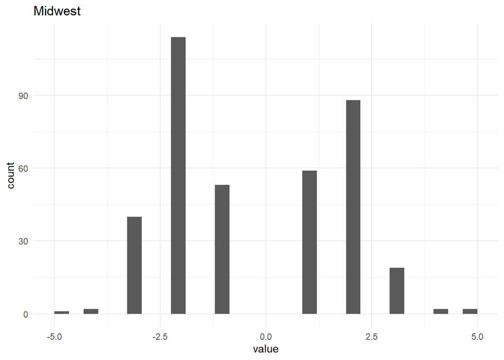

```r
# Distribution of positive and negative word sentiments
midwest_sent_plot <- ggplot(data = midwest_sentiment_affin,
       aes(x=value)
        )+
  geom_histogram()+
  ggtitle("Midwest")+
  theme_minimal()

midwest_sent_plot
```

The sentiment analysis using bing shows that the midwest uses more negative words than positive words. The nrc sentiment contradicts this and has a higher positive sentiment word count that negative, but also adds to this by showing that most of the words invoke a feeling of trust. The affin sentiment distribution shows that there is a slight favor of negative sentiment words in the midwests region’s newspapers, but the distribution is more even than the west coast distribution. Overall it appears that the negative and positive sentiment are about even in the midwest, indicating that there is not a strong lean in either positive or negative words. Overall it seems that the midwest is trying to instill a feeling of trust through talking about climate change.

### Word Cloud

3. Create a word cloud to see the popularity of the words

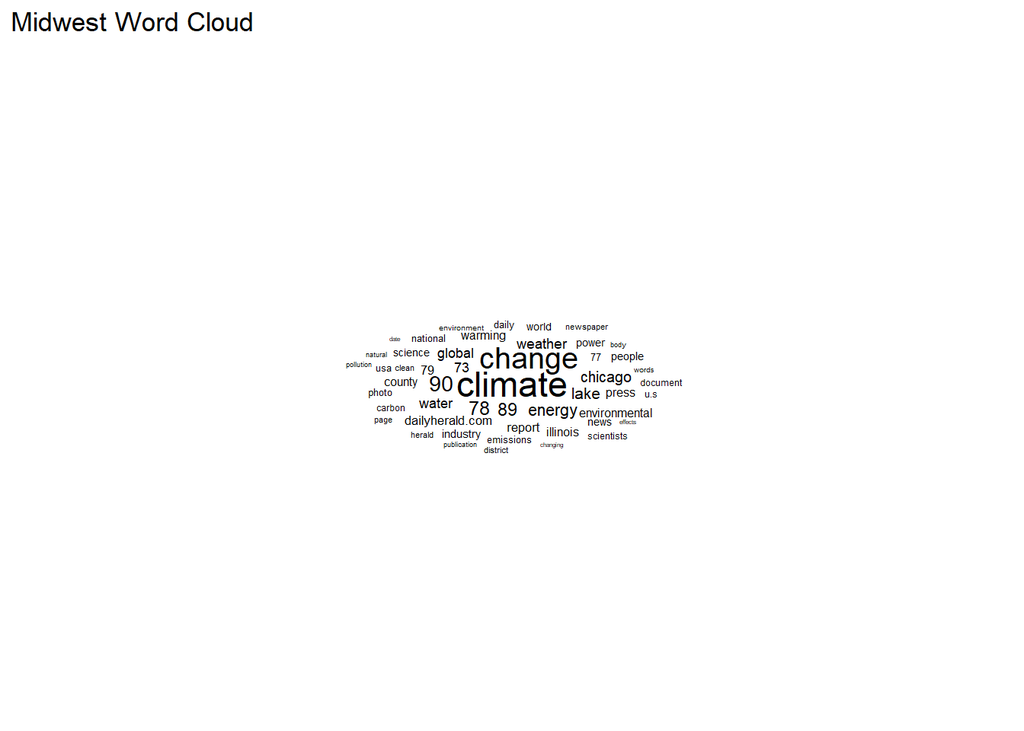

```r
set.seed(42)
midwest_cloud <- ggplot(midwest_inag[1:50,], aes(label = word, size = n)
       ) +
  geom_text_wordcloud() +
  theme_minimal() +
  ggtitle("Midwest Word Cloud")

midwest_cloud
```

We see that the most common words from the midwest region are some expected terms: climate, change, chicago, and then some other words that indicate the midwest’s main concerns with climate change: lake, water, warming, and energy. Overall these more specific words correlate with the climate change symptoms that the midwest is experiencing such as concerns with the great lakes and the warming of the midwest. Again overall the words seemed pretty neutral and did not sway in either a positive or negative direction, indicating that the midwest doesn’t appear to have very strong opinions on climate change.

## Mid Atlantic Region

### Word Frequency

#### Load in Mid Atlantic Region File

```r
# import data from compiled newspaper reading
mid_atl <- read_lines("MidAtlanticRegion.txt")
# make mid_atl into a tibble data structure
mid_atl <- tibble(mid_atl)
```

#### Word Frequencies

1. The first step in the process is finding the frequency of words per region.

```r
#change the data frame variables in mid_atl$mid_atl character types
mid_atl$mid_atl <- as.character(mid_atl$mid_atl)

mid_atl <- mid_atl %>%
  unnest_tokens(word, mid_atl) %>%
  anti_join(stop_words) %>% count(word, sort=TRUE)
# Top word Frequencies
head(mid_atl, 10)
```

```
## # A tibble: 10 x 2
##    word           n
##    <chr>      <int>
##  1 climate      552
##  2 change       419
##  3 90           189
##  4 78           181
##  5 energy       144
##  6 89           121
##  7 science      121
##  8 emissions    118
##  9 global       115
## 10 pittsburgh   115
```

### Sentiment Analysis

2. Using the word frequency from step 1, we use lexicons that help to classify the words in the documents using sentiment.

```r
mid_atl_sentiment_affin <- mid_atl %>% inner_join(get_sentiments('afinn'))
mid_atl_sentiment_nrc <- mid_atl %>% inner_join(get_sentiments('nrc'))
mid_atl_sentiment_bing <- mid_atl %>% inner_join(get_sentiments('bing'))

table(mid_atl_sentiment_bing$sentiment)
```

```
##
## negative positive
##      336      231
```

```r
table(mid_atl_sentiment_nrc$sentiment)
```

```
##
##        anger anticipation      disgust         fear          joy     negative
##          148          173           94          185          112          328
##     positive      sadness     surprise        trust
##          440          135           85          254
```

#### Plot Sentiment

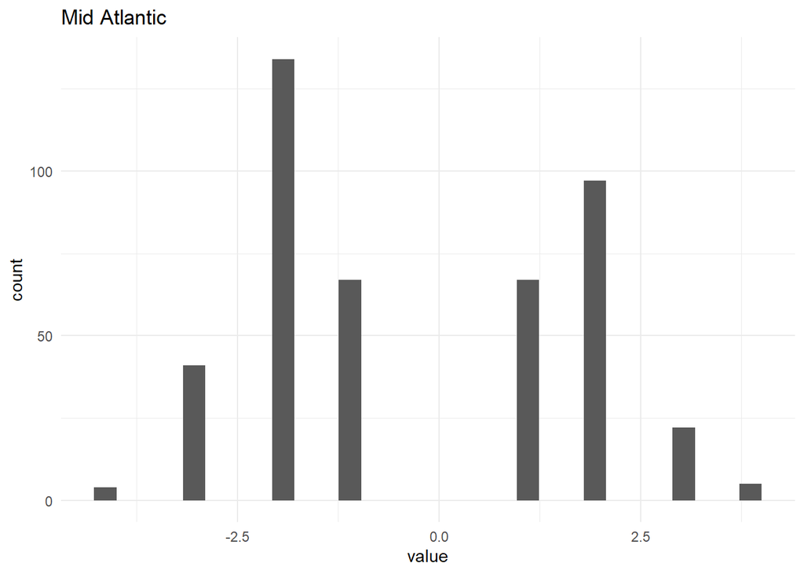

```r
mid_atl_sent_plot <- ggplot(data = mid_atl_sentiment_affin, aes(x=value))+geom_histogram()+ggtitle("Mid Atlantic")+theme_minimal()

mid_atl_sent_plot
```

From the graph, it seems that there are more words that have a negative sentiment, compared to the amount of words with a positive sentiment. This could be related to how Pennsylvania had recently been hit by Hurricane Ida and is still in the process of recovering from the natural disaster. Governor Tim Wolf also announced the Pennsylvania Climate Action Plan 2021 which may have increased the amount of articles released recently.

### Word Cloud

Here we use the ggplot package

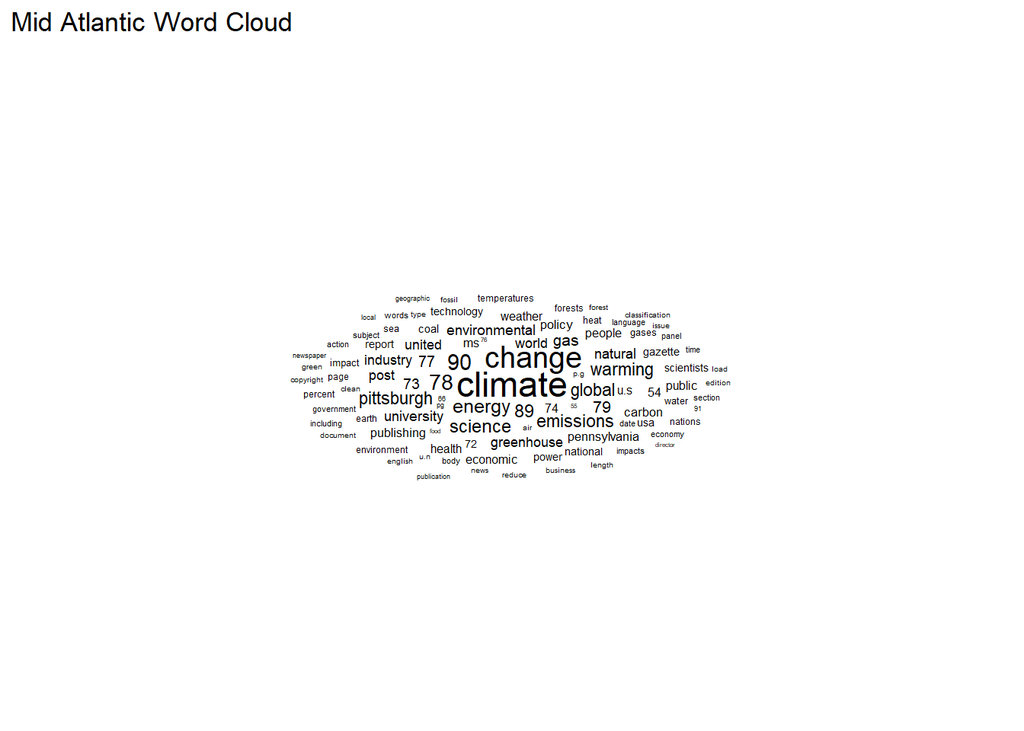

```r
set.seed(42)
mid_atl_cloud <- ggplot(mid_atl[1:100,], aes(label = word, size = n))+geom_text_wordcloud()+theme_minimal()+ ggtitle("Mid Atlantic Word Cloud")

mid_atl_cloud
```

#### Results:

There are frequent words in the documents that include science, emissions, global, energy, warming, natural, and university, excluding the words climate and change. I think it would be a good idea to look at different universities and see the overall support for climate change there as well as bigger urban areas. I would say that Pittsburgh is a big urban area that uses a lot of energy so there could be negative sentiment due to the energy consumption in the city. It seems like there has been a correlation with the science as evidence for climate change, so a more negative sentiment could also be seen in scholarly literature.

## NorthEast Region

### Word Frequency

#### Load in NorthEast Region File

```r
# import data from compiled newspaper reading
north <- read_lines("NorthEastRegion.txt")
# make mid_atl into a tibble data structure
north <- tibble(north)
```

#### Word Frequencies

1. The first step in the process is finding the frequency of words per region.

```r
#change the data frame variables in mid_atl$mid_atl character types
north$north <- as.character(north$north)

north <- north %>%
  unnest_tokens(word, north) %>%
  anti_join(stop_words) %>% count(word, sort=TRUE)
#top word frequencies
head(north, 10)
```

```
## # A tibble: 10 x 2
##    word         n
##    <chr>    <int>
##  1 climate    503
##  2 change     382
##  3 maine      299
##  4 90         158
##  5 78         112
##  6 89         102
##  7 warming     88
##  8 77          85
##  9 industry    85
## 10 usa         83
```

### Sentiment Analysis

2. Using the word frequency from step 1, we use lexicons that help to classify the words in the documents using sentiment.

```r
north_sentiment_affin <- north %>% inner_join(get_sentiments('afinn'))
north_sentiment_nrc <- north %>% inner_join(get_sentiments('nrc'))
north_sentiment_bing <- north %>% inner_join(get_sentiments('bing'))
```

#### Plot Sentiment

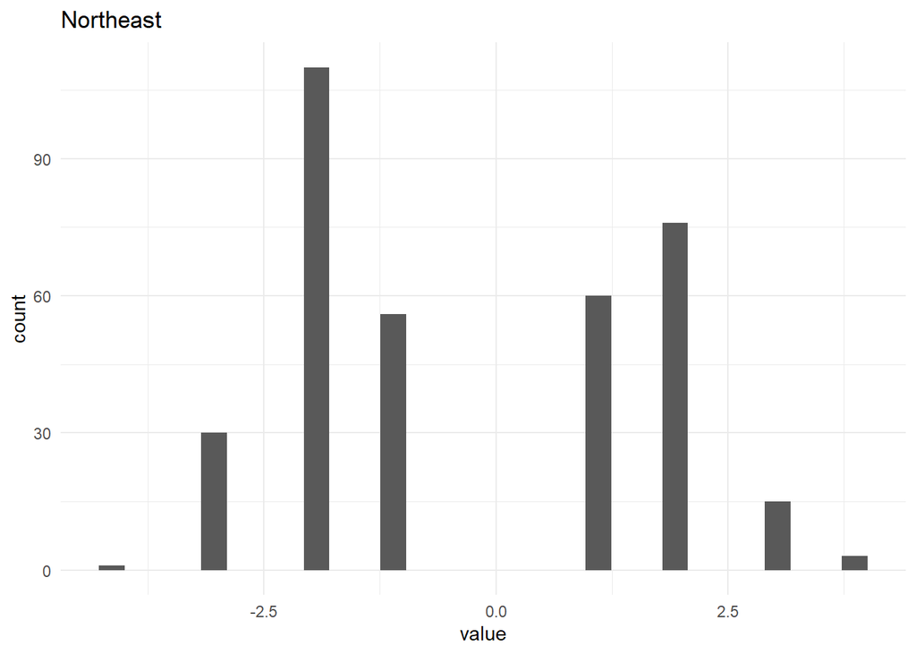

```r
north_sent_plot <- ggplot(data = north_sentiment_affin, aes(x=value))+geom_histogram()+ggtitle("Northeast")+theme_minimal()

north_sent_plot
```

From the graph, it seems like there are more words that have a negative sentiment compared to those with a positive sentiment.

### Word Cloud

Here we use the ggplot package

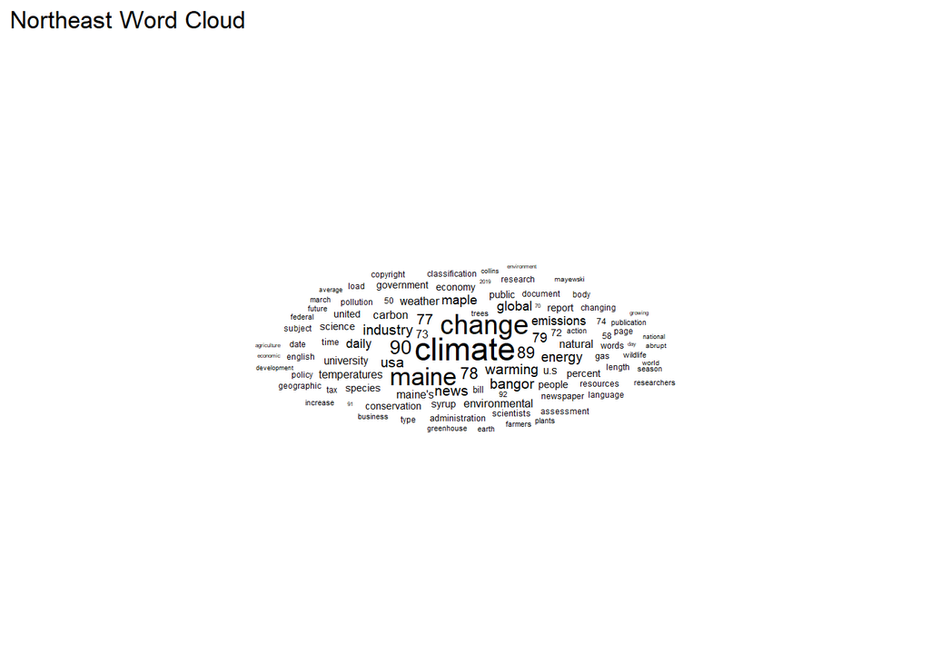

```r
set.seed(42)
north_cloud <- ggplot(north[1:100,], aes(label = word, size = n))+geom_text_wordcloud()+theme_minimal()+ ggtitle("Northeast Word Cloud")

north_cloud
```

## Southwest Region

### Word Frequency

#### Load in Southwest Region File

```r
texas_monthly <- read_lines("TexasMonthly.txt")
texas_monthly <- tibble(texas_monthly)
```

#### Word Frequencies

1. The first step in the process is finding the frequency of words per region.

```r
texas_monthly$texas_monthly <- as.character(texas_monthly$texas_monthly)
texas_monthly <- texas_monthly %>%
  unnest_tokens(word, texas_monthly)%>%
  anti_join(stop_words)%>%
  count(word, sort=TRUE)
head(texas_monthly, 10)
```

```
## # A tibble: 10 x 2
##    word           n
##    <chr>      <int>
##  1 climate      371
##  2 change       282
##  3 countries    234
##  4 government   210
##  5 minister     202
##  6 tuvalu       189
##  7 prime        174
##  8 island       159
##  9 parliament   147
## 10 agreement    122
```

### Sentiment Analysis

2. Using the word frequency from step 1, we use lexicons that help to classify the words in the documents using sentiment.

```r
texas_sentiment_affin <- texas_monthly %>%
  inner_join(get_sentiments("afinn"))
texas_sentiment_nrc <- texas_monthly %>%
  inner_join(get_sentiments("nrc"))
texas_sentiment_bing <- texas_monthly %>%
  inner_join(get_sentiments("bing"))
```

#### Plot Sentiment

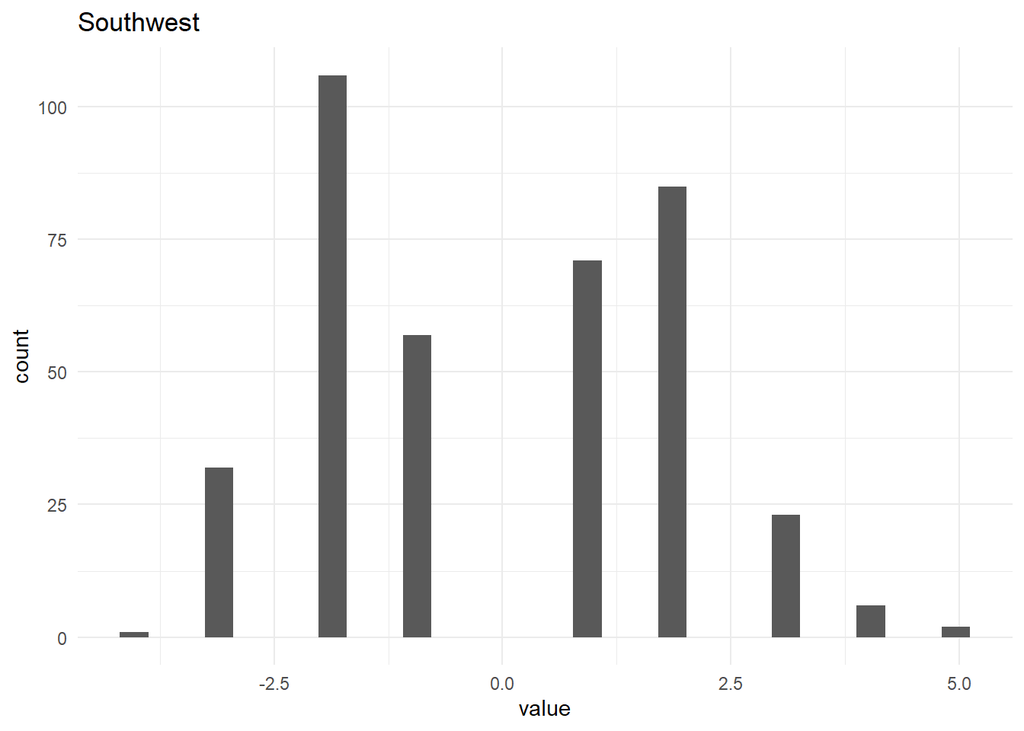

```r
southwest_sent_plot <- ggplot(data = texas_sentiment_affin,
       aes(x=value)
        )+
  geom_histogram()+
  ggtitle("Southwest")+
  theme_minimal()

southwest_sent_plot
```

### Word Cloud

Here we use the ggplot package

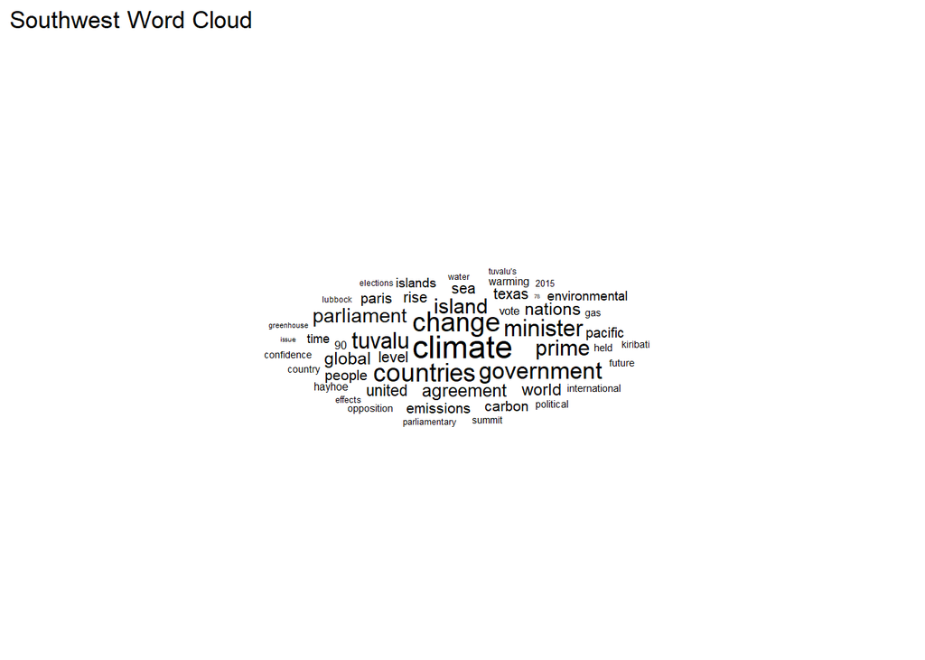

```r
set.seed(42)
southwest_cloud <- ggplot(texas_monthly[1:50,], aes(label = word, size = n)
       ) +
  geom_text_wordcloud() +
  ggtitle("Southwest Word Cloud") +
  theme_minimal()

southwest_cloud
```

#### Results

The word cloud for the southwest shows that conversation about climate change in the southwest is mostly about the government as well as international and global matters with words like “government”/“parliament”, and “countries”/“nations”. Overall, it seems like the southwest’s main concerns with climate change are both at the national and international level with a focus on the government/political aspects of it and how it affects the people.

## Southeast Region

### Word Frequency

#### Load in Southeast Region File

```r
atlanta_journal <- read_lines("TheAtlantaJournal.txt")
atlanta_journal <- tibble(atlanta_journal)
```

#### Word Frequencies

1. The first step in the process is finding the frequency of words per region.

```r
atlanta_journal$atlanta_journal <- as.character(atlanta_journal$atlanta_journal)
atlanta_journal <- atlanta_journal %>%
  unnest_tokens(word, atlanta_journal)%>%
  anti_join(stop_words)%>%
  count(word, sort=TRUE)
head(atlanta_journal,10)
```

```
## # A tibble: 10 x 2
##    word        n
##    <chr>   <int>
##  1 climate   199
##  2 change    143
##  3 global     70
##  4 warming    64
##  5 90         56
##  6 georgia    45
##  7 78         41
##  8 atlanta    40
##  9 89         39
## 10 health     36
```

### Sentiment Analysis

2. Using the word frequency from step 1, we use lexicons that help to classify the words in the documents using sentiment.

```r
atlanta_sentiment_affin <- atlanta_journal %>%
  inner_join(get_sentiments("afinn")) #using a inner join to match words and add the sentiment variable
atlanta_sentiment_nrc <- atlanta_journal %>%
  inner_join(get_sentiments("nrc"))
atlanta_sentiment_bing <- atlanta_journal %>%
  inner_join(get_sentiments("bing"))
```

#### Plot Sentiment

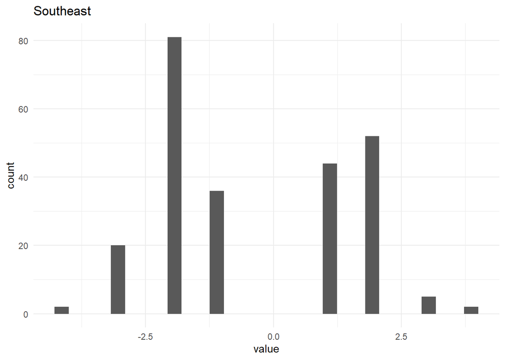

```r
southeast_sent_plot <- ggplot(data = atlanta_sentiment_affin,
       aes(x=value)
        )+
  geom_histogram()+
  ggtitle("Southeast")+
  theme_minimal()

southeast_sent_plot
```

### Word Cloud

Here we use the ggplot package

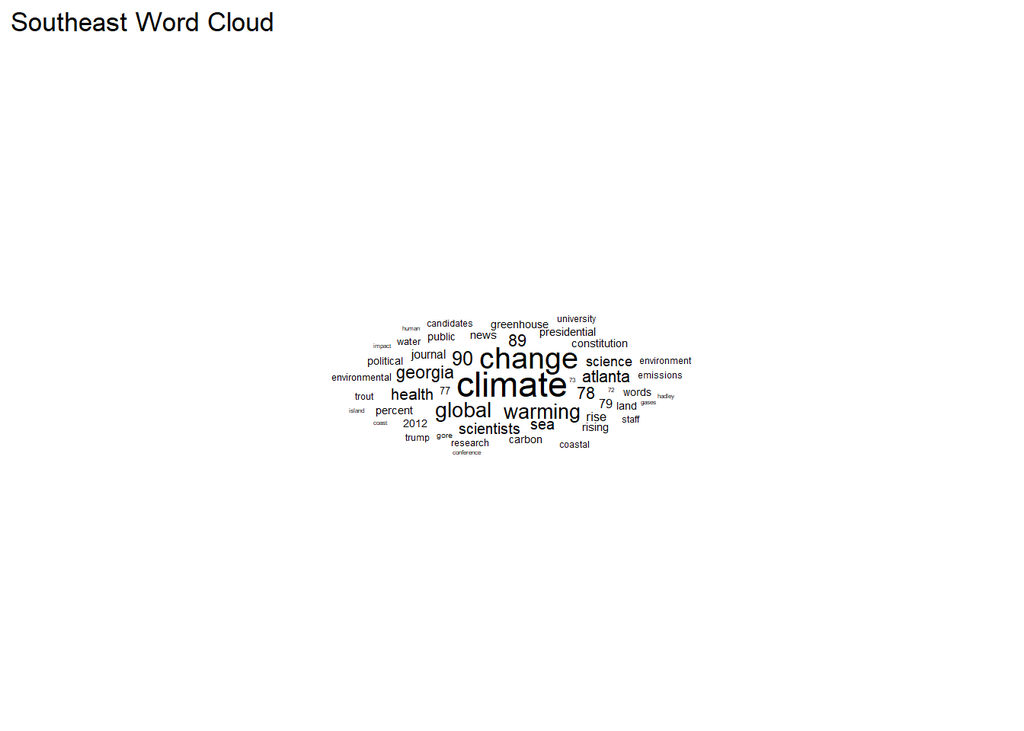

```r
set.seed(42)
southeast_cloud <- ggplot(atlanta_journal[1:50,], aes(label = word, size = n)
       ) +
  geom_text_wordcloud() +
  ggtitle("Southeast Word Cloud") +
  theme_minimal()

southeast_cloud
```

## National Comparison

```r
cali_inag_raw <- as.tibble(read_lines("cali-news.txt"))
midwest_inag_raw <- as.tibble(read_lines("midwest.txt"))
mid_atl_inag_raw <- as.tibble(read_lines("MidAtlanticRegion.txt"))
north_inag_raw <- as.tibble(read_lines("NorthEastRegion.txt"))
southwest_inag_raw <- as.tibble(read_lines("TexasMonthly.txt"))
southeast_inag_raw <-as.tibble(read_lines("TheAtlantaJournal.txt"))

data_prep <- function(x,y,z){
  i <- as_tibble(t(x))
  ii <- unite(i,"text",y:z,remove = TRUE,sep = "")
}


cali_inag_bag <- data_prep(cali_inag_raw,'V1','V2993')
midwest_inag_bag <- data_prep(midwest_inag_raw,'V1','V2376')
mid_atl_inag_bag <- data_prep(mid_atl_inag_raw,'V1','V2238')
north_inag_bag <- data_prep(north_inag_raw, 'V1', 'V2129')
southwest_inag_bag <- data_prep(southwest_inag_raw,'V1','V1458')
southeast_inag_bag <- data_prep(southeast_inag_raw, 'V1','V833')


region <- c("WestCoast", "Midwest", "Mid-Atlantic", "Northeast", "Southwest", "Southeast")

tf_idf_text <- tibble(region,text=t(tibble(cali_inag_bag, midwest_inag_bag, mid_atl_inag_bag, north_inag_bag, southwest_inag_bag, southeast_inag_bag,.name_repair = "universal")))

word_count <- tf_idf_text %>%
  unnest_tokens(word, text) %>%
  count(region, word, sort = TRUE)


total_words <- word_count %>%
  group_by(region) %>%
  summarize(total = sum(n))

inag_words <- left_join(word_count, total_words)

inag_words <- inag_words %>%
  bind_tf_idf(word, region, n)

head(inag_words, 100)
```

```
## # A tibble: 100 x 7
##    region       word      n total     tf   idf tf_idf
##    <chr>        <chr> <int> <int>  <dbl> <dbl>  <dbl>
##  1 Southwest    the    2916 42110 0.0692     0      0
##  2 WestCoast    the    2281 48270 0.0473     0      0
##  3 Midwest      the    1892 41106 0.0460     0      0
##  4 Mid-Atlantic the    1763 33509 0.0526     0      0
##  5 Southwest    of     1504 42110 0.0357     0      0
##  6 Northeast    the    1387 30115 0.0461     0      0
##  7 WestCoast    of     1189 48270 0.0246     0      0
##  8 Southwest    to     1166 42110 0.0277     0      0
##  9 WestCoast    and    1128 48270 0.0234     0      0
## 10 WestCoast    to     1121 48270 0.0232     0      0
## # ... with 90 more rows
```

```r
View(inag_words)
```

#### Overall tf-idf

**West Coast:** Lithium, rights, biden, desert, design

**Midwest:** paddock, tornado, restoration, district, lake

**Northeast:** bangor, maine’s, syrup, mayewski, farmers

**Mid-Atlantic:** pittsburgh, ms, co.section, carnegie, nuclear

**Southeast:** trout, marshes, brook, disappear, forests

**Southwest:** countries, minister, parliament, pacific, foreign

Excluding words that do not relate to climate change, the top 5 words for the tf-idf frequency by region are:

**West Coast:** Lithium, rights, biden, desert, design **Midwest:** paddock, tornado, restoration, district, lake **Northeast:** bangor, maine’s, syrup, mayewski, farmers **Mid-Atlantic:** carnegie, nuclear, ambassador, frozen, zoo **Southeast:** trout, marshes, brook, disappear, forests **Southwest:** countries, minister, parliament, pacific, foreign

When looking at climate change the west coast seems to lean in a political direction, while the midwest focuses more on farmland and damage caused by natural disasters. Similarly, the southwest leans in a political direction with an international/global focus, while the southeast leans in a natural/environmental direction. In terms of the northeast region, the industry seemed to be negatively impacted by climate change and the mid atlantic region is more focused on studies and literature it seems.

## Compare Word Clouds

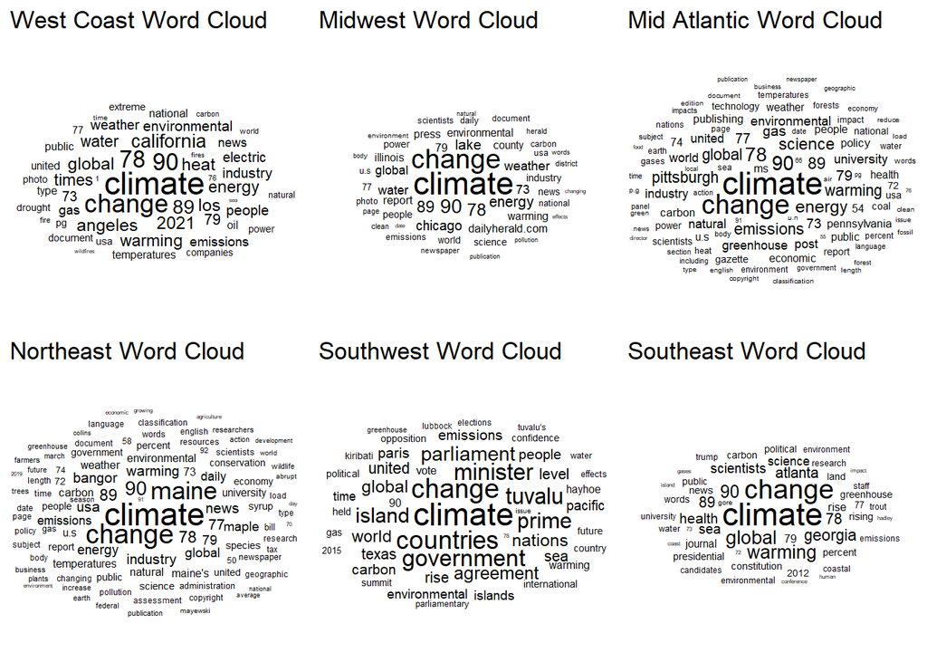

```r
ggarrange(west_cloud, midwest_cloud, mid_atl_cloud, north_cloud, southwest_cloud, southeast_cloud)
```

In general the trends mentioned earlier still stand, but it is important to note that across every region the word warming commonly appeared as well as environmental. This indicates that while the different regions may have different concerns about climate change, overall there is talk about warming of the planet and environmental impacts.

## Compare Sentiment Distribution

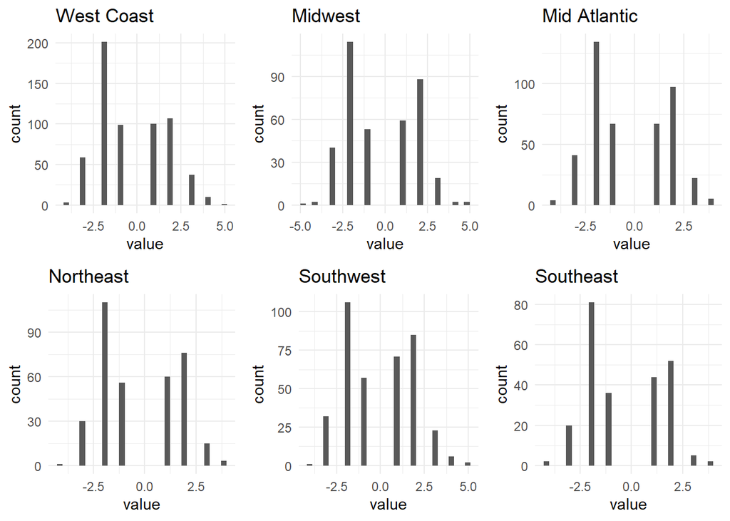

```r
ggarrange(west_sent_plot, midwest_sent_plot, mid_atl_sent_plot, north_sent_plot, southwest_sent_plot, southeast_sent_plot)
```

### Results:

Overall, it seems that the regions chosen had more of a negative sentiment than a positive sentiment for climate change. This trend is seen nationally, and while slightly more negative in some regions, overall sentiment on a national level is negative towards climate change. This is more likely due to the fact that climate change has many negative effects that are being experienced on a national scale and therefore the sentiment of the news talking about climate change is going to be negative.

### Recommendations:

We would recommend looking more specifically at the various stakeholders involved in climate change for the overall regions. Specifically we would recommend looking into universities as well as their faculty and carbon plants for each region respectively. Although there might be a higher negative sentiment in those areas, it would be interesting to find out the context as to why there is such a negative sentiment. In more recent news, we think more studies have been conducted on climate change and how the world is losing the necessary sources to survive at a faster pace than calculated, which leads into emotions like fear and anger. Overall, it would be important to look at the different stakeholders to determine where changes can be made to improve national sentiment into a more positive direction.